# STAT418 Assignment 3

Rui Qiao

5/22/2017

## SUSY Data Set

Detailed description: https://archive.ics.uci.edu/ml/datasets/SUSY

“This is a classification problem to distinguish between a signal process which produces supersymmetric particles and a background process which does not.”

“The first column is the class label (1 for signal, 0 for background), followed by the 18 features (8 low-level features then 10 high-level features). The first 8 features are kinematic properties measured by the particle detectors in the accelerator. The last ten features are functions of the first 8 features; these are high-level features derived by physicists to help discriminate between the two classes.”

The original data file (“SUSY.csv”) contains 5,000,000 observations and has file size of 2.39 GB. Uploading that file to the H2O cluster will generate an error (java.lang.OutOfMemoryError: Java heap space). H2O recommends that the memory should be four times the size of the data. Since the memory of my computer is 8GB, I decided to use a much smaller dataset.

This gives me a file named as “SUSY_high_aa” with 250,000 rows and 11 columns.

## Data Loading and Preparation

```r
# h2o.shutdown()
library(h2o)
h2o.init(nthreads = -1)
```

```
##
## H2O is not running yet, starting it now...
##
## Note:  In case of errors look at the following log files:
##     /var/folders/59/8nfp64tj00b2847bjhwdp87h0000gn/T//RtmpKMXGDo/h2o_rachel_started_from_r.out
##     /var/folders/59/8nfp64tj00b2847bjhwdp87h0000gn/T//RtmpKMXGDo/h2o_rachel_started_from_r.err
##
##
## Starting H2O JVM and connecting: ........ Connection successful!
##
## R is connected to the H2O cluster:
##     H2O cluster uptime:         11 seconds 704 milliseconds
##     H2O cluster version:        3.10.4.6
##     H2O cluster version age:    27 days
##     H2O cluster name:           H2O_started_from_R_rachel_txj403
##     H2O cluster total nodes:    1
##     H2O cluster total memory:   1.78 GB
##     H2O cluster total cores:    0
##     H2O cluster allowed cores:  0
##     H2O cluster healthy:        TRUE
##     H2O Connection ip:          localhost
##     H2O Connection port:        54321
##     H2O Connection proxy:       NA
##     H2O Internal Security:      FALSE
##     R Version:                  R version 3.3.2 (2016-10-31)
```

```r
col_names <- c("class", "MET_rel", "axial MET", "M_R", "M_TR_2", "R",
               "MT2", "S_R", "M_Delta_R", "dPhi_r_b", "cos(theta_r1)")

SUSY <- h2o.importFile("/Users/Rachel/Desktop/STAT418/SUSY/SUSY_high_aa",
                       destination_frame = "SUSY", col.names = col_names)
y <- "class"
x <- setdiff(names(SUSY),y)

# For binary classification, response should be a factor
SUSY[y] <- as.factor(SUSY[y])
summary(SUSY[y])
```

```
##  class
##  0:135621
##  1:114379
```

```r
# 1 for signal, 0 for background

# Split Data: train-valid-test
# Do not use cross-validation, dataset is large enough
parts <- h2o.splitFrame(SUSY, c(0.8,0.1), seed = 123)
SUSY_train <- parts[[1]]
SUSY_valid <- parts[[2]]
SUSY_test <- parts[[3]]
rm(parts)
```

## Logistic Regression (LR)

Logistic Regression (binomial classification): family = biomial

Lasso regularization: alpha = 1.0

Try various values for lambda.

```r
system.time({
  model_LR <- h2o.glm(x, y, training_frame = SUSY_train,
                      validation_frame = SUSY_valid,
                      family = "binomial",alpha = 1.0,
                      lambda = c(1, 0.5, 0.1, 0.01, 0.001, 0.0001,
                                 0.00001, 0.000001, 0.0000001, 0),
                      lambda_search = TRUE)
})
```

```
##    user  system elapsed
##   0.276   0.015   3.107
```

```r
h2o.auc(h2o.performance(model_LR, SUSY_valid))
```

```
## [1] 0.8358084
```

```r
model_LR
```

```
## Model Details:
## ==============
##
## H2OBinomialModel: glm
## Model ID:  GLM_model_R_1495656635074_1
## GLM Model: summary
##     family  link        regularization
## 1 binomial logit Lasso (lambda = 0.0 )
##                                                             lambda_search
## 1 nlambda = 100, lambda.max = 0.2116, lambda.min = 0.0, lambda.1se = -1.0
##   number_of_predictors_total number_of_active_predictors
## 1                         10                          10
##   number_of_iterations  training_frame
## 1                   16 RTMP_sid_ad75_3
##
## Coefficients: glm coefficients
##            names coefficients standardized_coefficients
## 1      Intercept    -2.634272                  0.186613
## 2        MET_rel     0.555961                  0.492320
## 3      axial MET     1.228831                  1.233204
## 4            M_R     1.530407                  0.955423
## 5         M_TR_2     3.965650                  2.309232
## 6              R    -0.645535                 -0.303853
## 7            MT2    -0.914201                 -0.784654
## 8            S_R    -2.368021                 -1.458796
## 9      M_Delta_R     1.055818                  0.657080
## 10      dPhi_r_b    -0.674294                 -0.294057
## 11 cos(theta_r1)     1.374599                  0.271452
##
## H2OBinomialMetrics: glm
## ** Reported on training data. **
##
## MSE:  0.1604399
## RMSE:  0.4005495
## LogLoss:  0.4911115
## Mean Per-Class Error:  0.2428545
## AUC:  0.8338958
## Gini:  0.6677917
## R^2:  0.3535774
## Null Deviance:  275996.4
```

[output cut: 42 more lines]

```
##
## Maximum Metrics: Maximum metrics at their respective thresholds
##                         metric threshold    value idx
## 1                       max f1  0.373038 0.742545 237
## 2                       max f2  0.161439 0.817859 347
## 3                 max f0point5  0.597765 0.783654 149
## 4                 max accuracy  0.505502 0.772986 183
## 5                max precision  0.998327 0.987342   1
## 6                   max recall  0.035313 1.000000 398
## 7              max specificity  0.999770 0.999408   0
## 8             max absolute_mcc  0.541517 0.545767 169
## 9   max min_per_class_accuracy  0.385250 0.759274 232
## 10 max mean_per_class_accuracy  0.433128 0.765954 211
##
## Gains/Lift Table: Extract with `h2o.gainsLift(<model>, <data>)` or `h2o.gainsLift(<model>, valid=<T/F>, xval=<T/F>)`
```

```r
s_1 <- h2o.auc(h2o.performance(model_LR, SUSY_test))

s1 <- h2o.auc(h2o.performance(model_LR, SUSY_test))
s1
```

```
## [1] 0.8327407
```

Among all the LR models. lambda = 0.0 will give largest auc for the validation dataset. The final choosen LR model has auc = 0.8327407 on test data set.

## Random Forest (RF)

```r
hyper_params <- list( ntrees = c(20,50), max_depth = c(10, 20), mtries = c(3,5))

RF_grid <- h2o.grid("randomForest",x = x, y = y, training_frame = SUSY_train,
                 validation_frame = SUSY_valid, nfolds = 0,
                 grid_id = "SUSY_RF_grid", hyper_params = hyper_params,
                 search_criteria = list(strategy = "Cartesian"),
                 stopping_metric = "AUC", stopping_tolerance = 0, stopping_rounds = 3)
RF_auc <- h2o.getGrid(RF_grid@grid_id, sort_by="auc", decreasing = TRUE)
RF_auc
```

```
## H2O Grid Details
## ================
##
## Grid ID: SUSY_RF_grid
## Used hyper parameters:
##   -  max_depth
##   -  mtries
##   -  ntrees
## Number of models: 8
## Number of failed models: 0
##
## Hyper-Parameter Search Summary: ordered by decreasing auc
##   max_depth mtries ntrees            model_ids                auc
## 1        20      3     50 SUSY_RF_grid_model_5 0.8602350557788119
## 2        10      5     50 SUSY_RF_grid_model_6 0.8596146049763522
## 3        10      5     20 SUSY_RF_grid_model_2 0.8595976061444148
## 4        20      5     50 SUSY_RF_grid_model_7 0.8594112589105218
## 5        10      3     50 SUSY_RF_grid_model_4 0.8574621656209978
## 6        10      3     20 SUSY_RF_grid_model_0 0.8566540549335303
## 7        20      5     20 SUSY_RF_grid_model_3  0.855519714346115
## 8        20      3     20 SUSY_RF_grid_model_1 0.8553522233454869
```

```r
range(RF_auc@summary_table$auc)
```

```
## [1] "0.8553522233454869" "0.8602350557788119"
```

Eight models tested. The highest auc is RF with max_depth = 20, mtries = 3, ntrees =50.

```r
system.time({
  model_RF <- h2o.randomForest(x = x, y = y, training_frame = SUSY_train,
                 validation_frame = SUSY_valid, nfolds = 0,
                 max_depth = 20, mtries = 3, ntrees =50)
})
```

```
##    user  system elapsed
##   0.328   0.017  22.633
```

```r
model_RF
```

```
## Model Details:
## ==============
##
## H2OBinomialModel: drf
## Model ID:  DRF_model_R_1495656635074_251
## Model Summary:
##   number_of_trees number_of_internal_trees model_size_in_bytes min_depth
## 1              50                       50             9374518        20
##   max_depth mean_depth min_leaves max_leaves mean_leaves
## 1        20   20.00000      13145      16436 14926.04000
##
##
## H2OBinomialMetrics: drf
## ** Reported on training data. **
## ** Metrics reported on Out-Of-Bag training samples **
##
## MSE:  0.1509354
## RMSE:  0.388504
## LogLoss:  0.4916275
## Mean Per-Class Error:  0.2272411
## AUC:  0.8522502
## Gini:  0.7045005
##
## Confusion Matrix (vertical: actual; across: predicted) for F1-optimal threshold:
##             0     1    Error           Rate
## 0       82874 25691 0.236642  =25691/108565
## 1       19947 71620 0.217840   =19947/91567
## Totals 102821 97311 0.228039  =45638/200132
##
## Maximum Metrics: Maximum metrics at their respective thresholds
##                         metric threshold    value idx
## 1                       max f1  0.375737 0.758373 220
## 2                       max f2  0.140119 0.824337 338
## 3                 max f0point5  0.646498 0.797695 120
## 4                 max accuracy  0.509935 0.785202 168
## 5                max precision  0.999987 0.988833   0
## 6                   max recall  0.002768 1.000000 399
## 7              max specificity  0.999987 0.998241   0
## 8             max absolute_mcc  0.555667 0.568942 152
## 9   max min_per_class_accuracy  0.386348 0.773601 216
```

[output cut: 18 more lines]

```
##
## Maximum Metrics: Maximum metrics at their respective thresholds
##                         metric threshold    value idx
## 1                       max f1  0.393997 0.765246 222
## 2                       max f2  0.178329 0.828530 321
## 3                 max f0point5  0.671927 0.807270 117
## 4                 max accuracy  0.510307 0.792916 176
## 5                max precision  0.993782 0.997247   2
## 6                   max recall  0.022773 1.000000 398
## 7              max specificity  0.999948 0.999704   0
## 8             max absolute_mcc  0.541845 0.583491 164
## 9   max min_per_class_accuracy  0.390280 0.781044 224
## 10 max mean_per_class_accuracy  0.476264 0.786917 190
##
## Gains/Lift Table: Extract with `h2o.gainsLift(<model>, <data>)` or `h2o.gainsLift(<model>, valid=<T/F>, xval=<T/F>)`
```

```r
s_2 <- h2o.auc(h2o.performance(model_RF, SUSY_test))

s2 <- h2o.auc(h2o.performance(model_RF, SUSY_test))
s2
```

```
## [1] 0.8570729
```

## Gradient Boosting Model (GBM)

1. max_depth = c(5, 10)
2. learn_rate = c(0.1, 0.2)
3. early stopping for determining the number of trees

(If not using early stopping and overtraining (increasing the number of iterations/trees), the process time will be too large. In fact, I originally do GBM without early stopping with a larger dataset. It took a great amount of running time and H2O ended up not having enough memory to run all the codes.)

```r
hyper_params = list(max_depth = c(5, 10),learn_rate = c(0.1, 0.2))

GBM_grid <- h2o.grid("gbm",x = x, y = y, training_frame = SUSY_train,
                 validation_frame = SUSY_valid, nfolds = 0,
                 grid_id = "SUSY_GBM_grid", hyper_params = hyper_params,
                 search_criteria = list(strategy = "Cartesian"),
                 stopping_tolerance = 0.02, stopping_rounds = 3,
                 score_tree_interval = 10
)
GBM_auc <- h2o.getGrid(GBM_grid@grid_id, sort_by="auc", decreasing = TRUE)
GBM_auc
```

```
## H2O Grid Details
## ================
##
## Grid ID: SUSY_GBM_grid
## Used hyper parameters:
##   -  learn_rate
##   -  max_depth
## Number of models: 4
## Number of failed models: 0
##
## Hyper-Parameter Search Summary: ordered by decreasing auc
##   learn_rate max_depth             model_ids                auc
## 1        0.1        10 SUSY_GBM_grid_model_2 0.8646611184404445
## 2        0.2         5 SUSY_GBM_grid_model_1 0.8637599670419558
## 3        0.2        10 SUSY_GBM_grid_model_3 0.8636433872148176
## 4        0.1         5 SUSY_GBM_grid_model_0 0.8616127192217606
```

```r
range(GBM_auc@summary_table$auc)
```

```
## [1] "0.8616127192217606" "0.8646611184404445"
```

```r
system.time({
  model_GBM <- h2o.gbm(x = x, y = y, training_frame = SUSY_train,
                 validation_frame = SUSY_valid,
                 max_depth = 1, learn_rate = 0.1)
})
```

```
##    user  system elapsed
##   0.234   0.009   6.528
```

```r
model_GBM
```

```
## Model Details:
## ==============
##
## H2OBinomialModel: gbm
## Model ID:  GBM_model_R_1495656635074_381
## Model Summary:
##   number_of_trees number_of_internal_trees model_size_in_bytes min_depth
## 1              50                       50                4886         1
##   max_depth mean_depth min_leaves max_leaves mean_leaves
## 1         1    1.00000          2          2     2.00000
##
##
## H2OBinomialMetrics: gbm
## ** Reported on training data. **
##
## MSE:  0.1700572
## RMSE:  0.4123799
## LogLoss:  0.517202
## Mean Per-Class Error:  0.2573108
## AUC:  0.8264452
## Gini:  0.6528904
##
## Confusion Matrix (vertical: actual; across: predicted) for F1-optimal threshold:
##            0      1    Error           Rate
## 0      76077  32488 0.299249  =32488/108565
## 1      19721  71846 0.215372   =19721/91567
## Totals 95798 104334 0.260873  =52209/200132
##
## Maximum Metrics: Maximum metrics at their respective thresholds
##                         metric threshold    value idx
## 1                       max f1  0.356019 0.733493 298
## 2                       max f2  0.246449 0.818867 371
## 3                 max f0point5  0.592587 0.768223 173
## 4                 max accuracy  0.472129 0.759814 234
## 5                max precision  0.964717 1.000000   0
## 6                   max recall  0.190765 1.000000 399
## 7              max specificity  0.964717 1.000000   0
## 8             max absolute_mcc  0.513814 0.518921 212
## 9   max min_per_class_accuracy  0.383136 0.747221 280
## 10 max mean_per_class_accuracy  0.429388 0.752646 255
```

[output cut: 17 more lines]

```
##
## Maximum Metrics: Maximum metrics at their respective thresholds
##                         metric threshold    value idx
## 1                       max f1  0.342418 0.733035 308
## 2                       max f2  0.257287 0.815643 366
## 3                 max f0point5  0.567041 0.768700 184
## 4                 max accuracy  0.513712 0.762496 211
## 5                max precision  0.964717 1.000000   0
## 6                   max recall  0.190765 1.000000 399
## 7              max specificity  0.964717 1.000000   0
## 8             max absolute_mcc  0.513712 0.525114 211
## 9   max min_per_class_accuracy  0.384518 0.746942 280
## 10 max mean_per_class_accuracy  0.458958 0.754805 237
##
## Gains/Lift Table: Extract with `h2o.gainsLift(<model>, <data>)` or `h2o.gainsLift(<model>, valid=<T/F>, xval=<T/F>)`
```

```r
s_3 <- h2o.auc(h2o.performance(model_GBM, SUSY_test))

s3 <- h2o.auc(h2o.performance(model_GBM, SUSY_test))
s3
```

```
## [1] 0.8254005
```

The final GBM give auc = 0.8254005 on test data.

## AUC/ ROC Comparation

```r
a <-as.data.frame(cbind(c("LR", "RF", "GBM"),c(s_1,s_2,s_3),c(s1,s2,s3)))
names(a) <- c("Model", "AUC on valid", "AUC on test")
a
```

```
##   Model      AUC on valid       AUC on test
## 1    LR 0.832740689296668 0.832740689296668
## 2    RF 0.857072869106545 0.857072869106545
## 3   GBM 0.825400493065195 0.825400493065195
```

Based on AUC comparison. Random Forest model with max_depth = 20, mtries = 3, ntrees =50 is the best model.

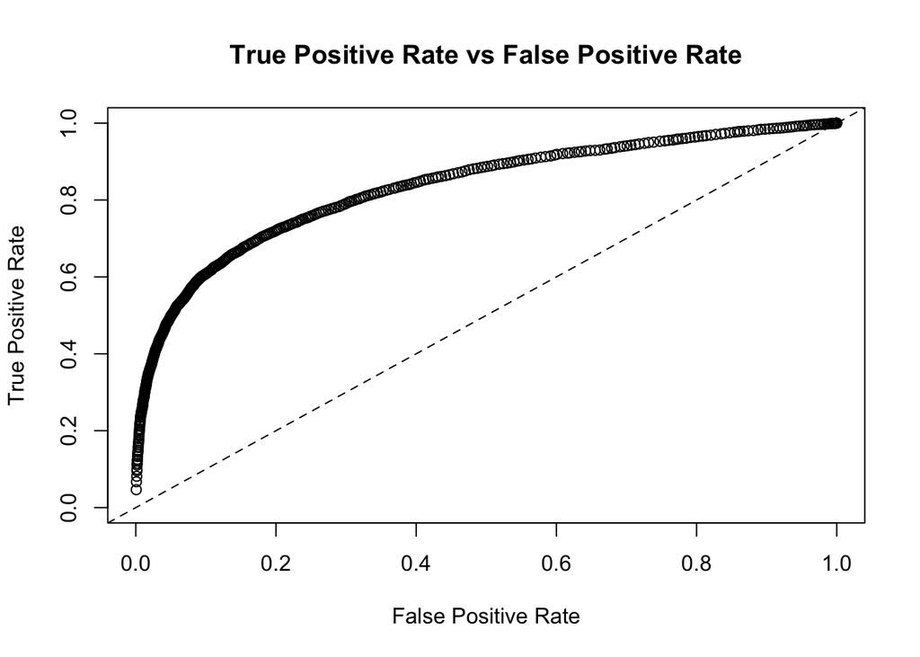

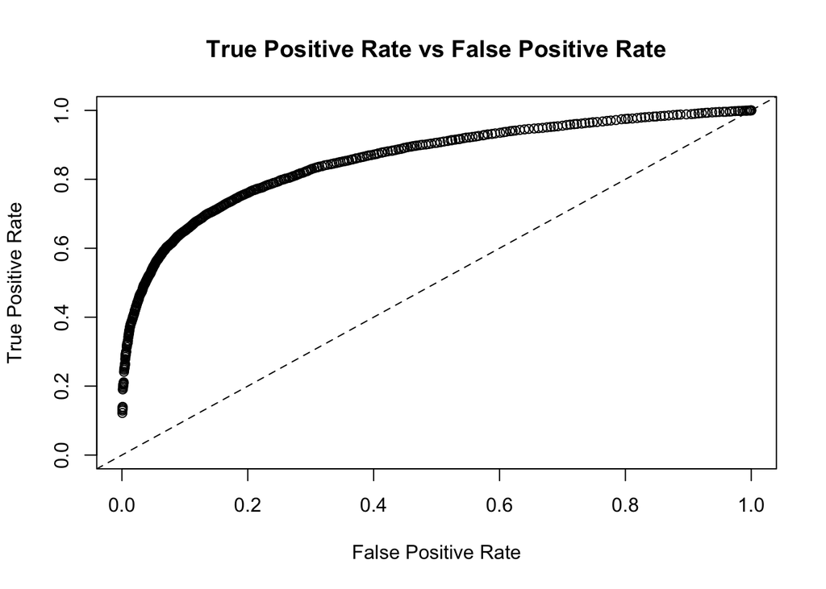

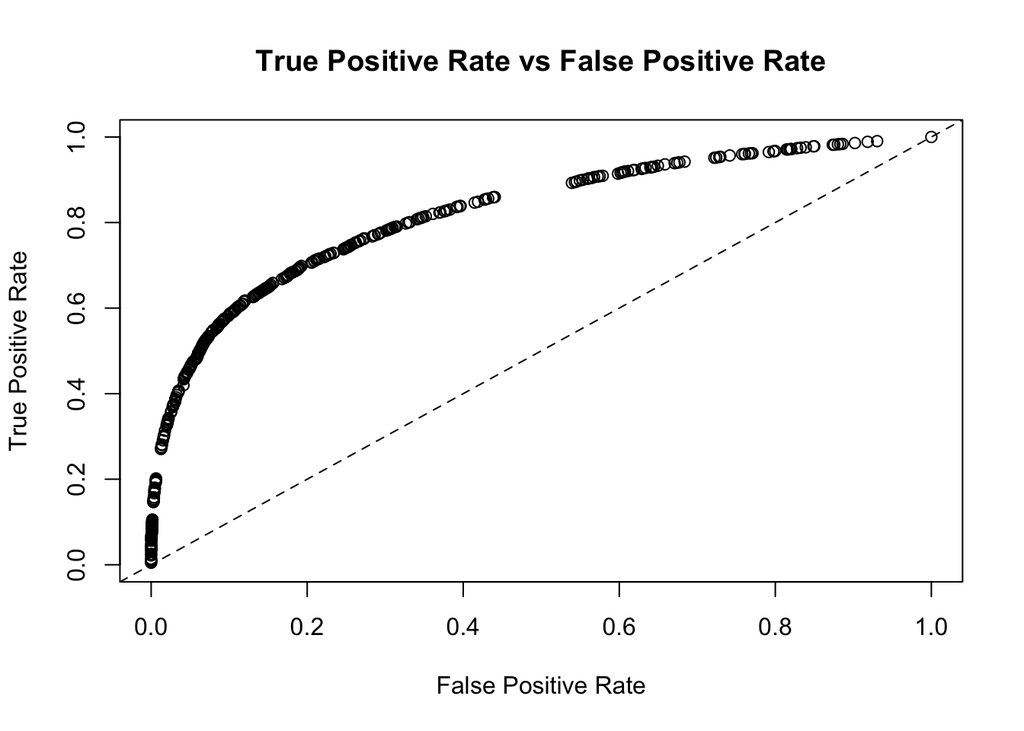

Notice: Need to take a further look at the GBM (ROC curve).